# SOL Bayesian Data Analysis

Kyle MacDonald

April 4, 2016

## Load packages and data

In this document, you will find the details of our Bayesian analysis for the paper, “Real-time Language Comprehension in American Sign Language.” Note that numerical values will be slightly different each time because of simulation variance.

```r
# Load data
d <- read.csv("../../processed_data/sol_ss_all_600_2500.csv")

# Standardize the data
d %<>%
    mutate(C_D_count = ifelse(is.na(C_D_count), 0, C_D_count),
           total_trials_shifting = C_T_count + C_D_count,
           Sub.Num = as.character(Sub.Num)) %>%
    dplyr::select(Sub.Num, age_peek_months, age_group, signs_produced, C_T_count, total_trials_shifting,
                  median_rt = median_ct_rt, C_T_prop, mean_prop_looking_TD,
                  value_cat, age_group_collapsed, hearing_status_participant)

d_all <- d %>% filter(value_cat == "Target" | value_cat == "Distractor")

d %<>% filter(age_group_collapsed == "Kids", value_cat == "Target")  %>%
    mutate(age.s = (age_peek_months - mean(age_peek_months, na.rm=T)) / sd(age_peek_months, na.rm=T),
           acc.s = (mean_prop_looking_TD - mean(mean_prop_looking_TD)) / sd(mean_prop_looking_TD),
           rt.s = (median_rt - mean(median_rt)) / sd(median_rt),
           voc.s = (signs_produced - mean(signs_produced)) / sd(signs_produced))

d_voc <- d %>%
    filter(is.na(signs_produced) == F) %>%
    mutate(age.s = (age_peek_months - mean(age_peek_months, na.rm=T)) / sd(age_peek_months, na.rm=T),
           acc.s = (mean_prop_looking_TD - mean(mean_prop_looking_TD)) / sd(mean_prop_looking_TD),
           rt.s = (median_rt - mean(median_rt)) / sd(median_rt),
           voc.s = (signs_produced - mean(signs_produced)) / sd(signs_produced))
```

## Defining priors

We set the standard deviation on the Gaussian prior for the slope parameter using estimated gains in accuracy and RT between 18-24 months in Fernald et al., (2008).

- RT estimate: is 50ms change with each month of development
- Acc estimate is .0167 change with each month of development

## Age as categorical variable

All categorical models were fit using STAN (Team 2016), and are based on code adapted from McElreath (2016).

First we need to create dummy variables for the relevant group comparisons.

```r
d_model <- d_all %>%
    mutate(age_group_older = ifelse(age_group == ">= 27 Months", 1, 0),
           age_group_adults = ifelse(age_group == "Adults", 1, 0),
           age_group_clean = ifelse(age_group_older == 1, "Older",
                                    ifelse(age_group_adults == 1, "Adult",
                                           "Younger")),
           age_group_adults_collapsed = ifelse(age_group == "Adults", 1, 0),
           hearing_group = ifelse(hearing_status_participant == "hearing", 1, 0))
```

### CODA vs. Deaf

Compare accuracy for deaf and hearing kids. All priors vague since here we are just concerned with parameter estimation.

```r
acc_hearing_stat_cat_targ.m <- map2stan(
    alist(
        mean_prop_looking_TD ~ dnorm(mu, sigma),
        mu <- Intercept + b_Hearing*hearing_group,
        Intercept ~ dnorm(0.6, 10),
        b_Hearing ~ dnorm(0, 1),
        sigma ~ dunif(0, 10)
    ),
    data = select(filter(d_model, value_cat == "Target", age_group_collapsed == "Kids"),
                  mean_prop_looking_TD, hearing_group))
```

```r
# get samples
post_hearing_stat.acc <- extract.samples(acc_hearing_stat_cat_targ.m)
mu.hearing <- post_hearing_stat.acc$Intercept
mu.deaf <- post_hearing_stat.acc$b_Hearing + post_hearing_stat.acc$Intercept
post_df_hearing_stat.acc <- data.frame(mu.hearing, mu.deaf)
precis(post_df_hearing_stat.acc)

# test contrast
diff.deaf.hearing <- mu.hearing - mu.deaf
quantile(diff.deaf.hearing, probs = c(0.025, 0.5, 0.975))
```

Compare RT for deaf and hearing kids.

```r
rt_hearing_stat.m <- map2stan(
    alist(
        median_rt ~ dnorm(mu, sigma),
        mu <- Intercept + b_Hearing*hearing_group,
        Intercept ~ dnorm(1300, 100),
        b_Hearing ~ dnorm(0, 500),
        sigma ~ dunif(0, 500)
    ),
    data = select(filter(d_model, value_cat == "Target", age_group_collapsed == "Kids"),
                  median_rt, hearing_group)
)

# extract samples
post_hearing_stat.rt <- extract.samples(rt_hearing_stat.m)
mu.hearing.rt <- as.numeric(post_hearing_stat.rt$Intercept)
mu.deaf.rt <- as.numeric(post_hearing_stat.rt$b_Hearing + post_hearing_stat.rt$Intercept)
post_hearing_stat.rt <- data.frame(mu.hearing.rt, mu.deaf.rt)
precis(post_hearing_stat.rt)

# test contrast
diff.deaf.hearing.rt <- mu.hearing.rt - mu.deaf.rt
quantile(diff.deaf.hearing.rt, probs = c(0.025, 0.5, 0.975))
```

### Target looking for each age group

Test older vs. younger age group.

```r
acc_age_cat_targ.m <- map2stan(
    alist(
        mean_prop_looking_TD ~ dnorm(mu, sigma),
        mu <- Intercept + b_Older*age_group_older + b_Adults*age_group_adults,
        Intercept ~ dnorm(0.6, 10),
        b_Older ~ dnorm(0, 1),
        b_Adults ~ dnorm(0, 1),
        sigma ~ dunif(0, 10)
    ),
    data = select(filter(d_model, value_cat == "Target"), mean_prop_looking_TD,
                         age_group_adults, age_group_older)
)

post_ages.acc <- extract.samples(acc_age_cat_targ.m)

mu.younger <- post_ages.acc$Intercept
mu.older <- post_ages.acc$b_Older + post_ages.acc$Intercept
mu.adults <- post_ages.acc$b_Adults + post_ages.acc$Intercept
post_df.acc <- data.frame(mu.younger, mu.older, mu.adults)
precis(post_df.acc)

# contrast older vs. younger (target looking)
diff.old.young <- mu.younger - mu.older
quantile(diff.old.young, probs = c(0.025, 0.5, 0.975))
```

### RT for each age group

```r
rt_age_cat.m <- map2stan(
    alist(
        median_rt ~ dnorm(mu, sigma),
        mu <- Intercept + b_Older*age_group_older + b_Adults*age_group_adults,
        Intercept ~ dnorm(1300, 100),
        b_Older ~ dnorm(0, 500),
        b_Adults ~ dnorm(0, 500),
        sigma ~ dunif(0, 500)
    ),
    data = select(filter(d_model, value_cat == "Target"), median_rt, age_group_older, age_group_adults)
)

post_ages.rt <- extract.samples(rt_age_cat.m)

mu.younger.rt <- as.numeric(post_ages.rt$Intercept)
mu.older.rt <- as.numeric(post_ages.rt$b_Older + post_ages.rt$Intercept)
mu.adults.rt <- as.numeric(post_ages.rt$b_Adults + post_ages.rt$Intercept)
post_df.rt <- data.frame(mu.younger.rt, mu.older.rt, mu.adults.rt)
precis(post_df.rt)

diff.old.young.rt <- mu.older.rt - mu.younger.rt
quantile(diff.old.young.rt, probs = c(0.025, 0.5, 0.975))
```

### Target vs. Distractor looking for each age group

```r
acc_age_cat_dist.m <- map2stan(
    alist(
        mean_prop_looking_TD ~ dnorm(mu, sigma),
        mu <- Intercept + b_Older*age_group_older + b_Adults*age_group_adults,
        Intercept ~ dnorm(0.6, 10),
        b_Older ~ dnorm(0, 1),
        b_Adults ~ dnorm(0, 1),
        sigma ~ dunif(0, 10)
    ),
    data = select(filter(d_model, value_cat == "Distractor"), mean_prop_looking_TD,
                         age_group_adults, age_group_older)
)

# get samples
post_ages.dist <- extract.samples(acc_age_cat_dist.m)

# Distractor: compute averages for each group (intercept is youngest kids)
mu.younger.dist <- post_ages.dist$Intercept
mu.older.dist <- post_ages.dist$b_Older + post_ages.dist$Intercept
mu.adults.dist <- post_ages.dist$b_Adults + post_ages.dist$Intercept
post_df.dist <- data.frame(mu.younger.dist, mu.older.dist, mu.adults.dist)
precis(post_df.dist)

# Merge Target and Distractor looking posterior samples
post_df.dist$looking_type <- "Distractor"
post_df.dist %<>% rename(mu.younger = mu.younger.dist,
                         mu.older = mu.older.dist,
                         mu.adults = mu.adults.dist)
post_df.acc$looking_type <- "Target"
post_df.acc_all <- rbind(post_df.acc, post_df.dist)

# target vs. distractor looking at each time point
diff.targ.dist.young <- mu.younger - mu.younger.dist
quantile(diff.targ.dist.young, probs = c(0.025, 0.5, 0.975))

diff.targ.dist.older <- mu.older - mu.older.dist
quantile(diff.targ.dist.older, probs = c(0.025, 0.5, 0.975))

diff.targ.dist.adults <- mu.adults - mu.adults.dist
quantile(diff.targ.dist.adults, probs = c(0.025, 0.5, 0.975))
```

### Accuracy and RT for kids compared to adults

```r
acc_age_cat_targ.m.collapsed <- map2stan(
    alist(
        mean_prop_looking_TD ~ dnorm(mu, sigma),
        mu <- Intercept + b_Adults*age_group_adults_collapsed,
        Intercept ~ dnorm(0.6, 10),
        b_Adults ~ dnorm(0, 1),
        sigma ~ dunif(0, 10)
    ),
    data = select(filter(d_model, value_cat == "Target"), mean_prop_looking_TD,
                         age_group_adults_collapsed)
)

post_ages.acc_collapsed <- extract.samples(acc_age_cat_targ.m.collapsed)

mu.kids.collapsed <- post_ages.acc_collapsed$Intercept
mu.adults.collapsed <- post_ages.acc_collapsed$b_Adults + post_ages.acc_collapsed$Intercept
post_df.acc.collapsed <- data.frame(mu.kids.collapsed, mu.adults.collapsed)
precis(post_df.acc.collapsed)

diff.old.young.acc.collapsed <- mu.kids.collapsed - mu.adults.collapsed
quantile(diff.old.young.acc.collapsed, probs = c(0.025, 0.5, 0.975))
```

```r
rt_age_cat_collapsed.m <- map2stan(
    alist(
        median_rt ~ dnorm(mu, sigma),
        mu <- Intercept + b_Adults*age_group_adults_collapsed,
        Intercept ~ dnorm(1300, 100),
        b_Adults ~ dnorm(0, 500),
        sigma ~ dunif(0, 500)
    ),
    data = select(filter(d_model, value_cat == "Target"), median_rt, age_group_adults_collapsed)
)

post_ages.rt_collapsed <- extract.samples(rt_age_cat_collapsed.m)

mu.kids.rt.collapsed <- as.numeric(post_ages.rt_collapsed$Intercept)
mu.adults.rt.collapsed <- as.numeric(post_ages.rt_collapsed$b_Adults + post_ages.rt_collapsed$Intercept)
post_df.rt.collapsed <- data.frame(mu.kids.rt.collapsed, mu.adults.rt.collapsed)
precis(post_df.rt.collapsed)

diff.old.young.rt.collapsed <- mu.kids.rt.collapsed - mu.adults.rt.collapsed
quantile(diff.old.young.rt.collapsed, probs = c(0.025, 0.5, 0.975))
```

### Bayes Factor Analysis for CODA vs. Deaf comparison

From Lee and Wagenmakers (2014) Ch.8 on two-sample comparisons.

“In our Bayesian approach of making inferences about the means, we rescale the data so that one group has mean 0 and standard deviation 1. This rescaling procedure ensures that the prior distributions for the parameters hold regardless of the scale of measurement. Therefore it does not matter whether, say, response times are measured in seconds or in milliseconds.”

```r
# get accuracy data
x <- d %>%
    filter(value_cat == "Target", age_group_collapsed == "Kids",
           hearing_status_participant == "deaf") %>%
    select(mean_prop_looking_TD)

y <- d %>%
    filter(value_cat == "Target", age_group_collapsed == "Kids",
           hearing_status_participant == "hearing") %>%
    select(mean_prop_looking_TD)

x <- x$mean_prop_looking_TD
y <- y$mean_prop_looking_TD

n1 <- length(x)
n2 <- length(y)

# Rescale data
y <- y - mean(x)
y <- y/sd(x)
x <- (x-mean(x))/sd(x); data <- list("x", "y", "n1", "n2") # to be passed on to JAGS

myinits <- list(
    list(delta = rnorm(1,0,3), mu = rnorm(1,0,1), sigmatmp = runif(1,0,5)),
    list(delta = rnorm(1,0,3), mu = rnorm(1,0,1), sigmatmp = runif(1,0,5)),
    list(delta = rnorm(1,0,3), mu = rnorm(1,0,1), sigmatmp = runif(1,0,5)))

# Parameters to be monitored
parameters <- c("delta")

# The following command calls JAGS with specific options.
# For a detailed description see the R2jags documentation.
samples <- jags(data, inits=myinits, parameters,
                model.file = "models/categorical_model.txt",
                n.chains=3, n.iter=10000, n.burnin=5000, n.thin=1, DIC=T)

df <- data.frame(delta.posterior=samples$BUGSoutput$sims.list$delta)

# Fits a density using spliens to approx. log-density
# uses 1997 knot and deletion algorithm
fit.posterior<- logspline(df$delta.posterior) #NEW

# 95% CI for log-density (of posterior of effect size)
ci.low<-qlogspline(0.025,fit.posterior)
ci.hi<-qlogspline(0.975,fit.posterior)

posterior<-dlogspline(0, fit.posterior) # pdf @ delta=0
prior<-dcauchy(0) # height of order--restricted prior
BF01<-posterior/prior # bayes factor
BF01
```

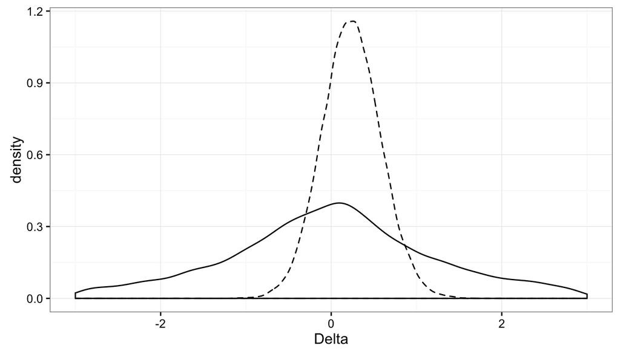

```r
df$delta.prior<-rcauchy(length(df$delta.posterior),0,1)

ggplot(data=df)+
    geom_density(aes(x=delta.posterior),linetype='dashed')+
    geom_density(aes(x=delta.prior))+
    theme_bw()+
    xlim(-3,3)+
    xlab('Delta')
```

```r
# get accuracy data
x <- d %>%
    filter(value_cat == "Target", age_group_collapsed == "Kids",
           hearing_status_participant == "deaf") %>%
    select(median_rt)

y <- d %>%
    filter(value_cat == "Target", age_group_collapsed == "Kids",
           hearing_status_participant == "hearing") %>%
    select(median_rt)

x <- x$median_rt
y <- y$median_rt

n1 <- length(x)
n2 <- length(y)

# Rescale data
y <- y - mean(x)
y <- y/sd(x)
x <- (x-mean(x))/sd(x); data <- list("x", "y", "n1", "n2") # to be passed on to JAGS

myinits <- list(
    list(delta = rnorm(1,0,3), mu = rnorm(1,0,1), sigmatmp = runif(1,0,5)),
    list(delta = rnorm(1,0,3), mu = rnorm(1,0,1), sigmatmp = runif(1,0,5)),
    list(delta = rnorm(1,0,3), mu = rnorm(1,0,1), sigmatmp = runif(1,0,5)))

# Parameters to be monitored
parameters <- c("delta")

# The following command calls JAGS with specific options.
# For a detailed description see the R2jags documentation.
samples <- jags(data, inits=myinits, parameters,
                model.file = "models/categorical_model.txt",
                n.chains=3, n.iter=10000, n.burnin=5000, n.thin=1, DIC=T)

df <- data.frame(delta.posterior=samples$BUGSoutput$sims.list$delta)

# Fits a density using spliens to approx. log-density
# uses 1997 knot and deletion algorithm
fit.posterior<- logspline(df$delta.posterior)

# 95% CI for log-density (of posterior of effect size)
ci.low<-qlogspline(0.025,fit.posterior)
ci.hi<-qlogspline(0.975,fit.posterior)

posterior<-dlogspline(0, fit.posterior) # pdf @ delta=0
prior<-dcauchy(0) # height of order--restricted prior
BF01<-posterior/prior # bayes factor
BF01
```

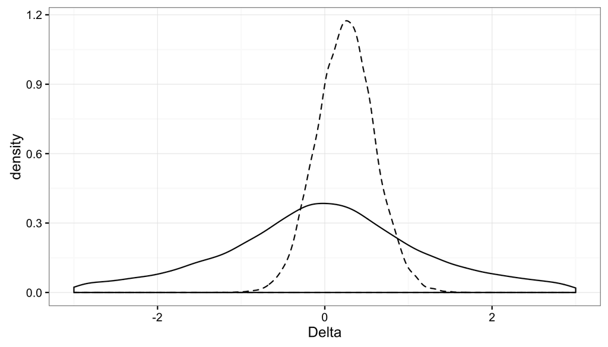

```r
df$delta.prior<-rcauchy(length(df$delta.posterior),0,1)

ggplot(data=df)+
    geom_density(aes(x=delta.posterior),linetype='dashed')+
    geom_density(aes(x=delta.prior))+
    theme_bw()+
    xlim(-3,3)+
    xlab('Delta')
```

### Summary barplots for categorical analyses

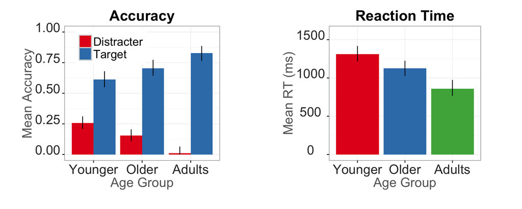

```r
# Accuracy: MAP and HDI for each age group
post_df.acc_all %<>% gather(key = age_group, value = post_sample, mu.younger:mu.adults)

ms_all <- post_df.acc_all %>%
    group_by(age_group, looking_type) %>%
    summarise(mean_post = mean(post_sample),
              HDI_lower = HDIofMCMC(post_sample, credMass = 0.95)[1],
              HDI_upper = HDIofMCMC(post_sample, credMass = 0.95)[2]) %>%
    mutate(HDI_lower = ifelse(HDI_lower <= 0, 0, HDI_lower),
           looking_type = ifelse(looking_type == "Distractor", "Distracter", "Target"))

######### Now plot bar graph of MAP and HDI for target/distractor looking ############

# RT: MAP and HDI for each age group
post_df.rt %<>% gather(key = age_group, value = post_sample)

ms_all_rt <- post_df.rt %>%
    group_by(age_group) %>%
    summarise(mean_post = mean(post_sample),
              HDI_lower = HDIofMCMC(post_sample, credMass = 0.95)[1],
              HDI_upper = HDIofMCMC(post_sample, credMass = 0.95)[2])

# Bar Plot
all_acc <- ggplot(aes(x = age_group, y = mean_post, fill = looking_type), data = ms_all) +
    geom_bar(stat = "identity", position="dodge") +
    geom_linerange(aes(ymin = HDI_lower,
                       ymax = HDI_upper),
                   position = position_dodge(width = 0.9)) +
    xlab("Age Group") +
    ylab("Mean Accuracy") +
    coord_cartesian(ylim=c(0, 1)) +
    scale_fill_brewer(type = "qual", palette = "Set1") +
    guides(fill=guide_legend(title=NULL)) +
    scale_x_discrete(labels=c("Younger", "Older", "Adults")) +
    theme_bw() +
    theme(plot.title = element_text(face = "bold", size = 20),
          axis.title.x = element_text(colour="grey40",size=18,
                                      angle=0,hjust=0.5,vjust=0,face="plain"),
          axis.title.y = element_text(colour="grey40",size=18,
                                      angle=90,hjust=0.5,vjust=0.5,face="plain"),
          axis.text.x = element_text(colour="grey20",size=18,
                                     angle=0,hjust=0.5,vjust=0,face="plain"),
          axis.text.y = element_text(colour="grey20",size=18,
                                     angle=0,hjust=0.5,vjust=0,face="plain"),
          plot.margin = unit(c(0.5,2,1,1), "cm"),
          legend.position = c(0.3, 0.85),
          legend.text = element_text(size = 16)) +
    ggtitle("Accuracy")

all_rt <- ggplot(aes(x= age_group, y = mean_post, fill = age_group), data = ms_all_rt) +
    geom_bar(stat = "identity") +
    geom_linerange(aes(ymax = HDI_upper, ymin = HDI_lower)) +
    scale_fill_brewer(type = "qual", palette = "Set1") +
    guides(fill=F) +
    xlab("Age Group") +
    ylab("Mean RT (ms)") +
    scale_x_discrete(labels=c("Younger", "Older", "Adults")) +
    ylim(0, 1600) +
    theme_bw() +
    theme(plot.title = element_text(face = "bold", size = 20),
          axis.title.x = element_text(colour="grey40",size=18,
                                      angle=0,hjust=0.5,vjust=0,face="plain"),
          axis.title.y = element_text(colour="grey40",size=18,
                                      angle=90,hjust=0.5,vjust=0.5,face="plain"),
          axis.text.x = element_text(colour="grey20",size=18,
                                     angle=0,hjust=0.5,vjust=0,face="plain"),
          axis.text.y = element_text(colour="grey20",size=18,
                                     angle=0,hjust=0.5,vjust=0,face="plain"),
          plot.margin = unit(c(0.5,2,1,1), "cm")) +
    ggtitle("Reaction Time")

gridExtra::grid.arrange(all_acc, all_rt, ncol = 2)
```

## Univariate regressions predicting processing measures

All models fit using JAGS (Plummer and others 2003) and based on models from Ch. 17 in Kruschke (2014).

First, we need to set the parameters for the MCMC simulations. This will be the same across all models. The key parameter of interest is the standardized slope: zbeta1. This encodes the strength of the linear relationship between the predictor variable and the outcome.

```r
adaptSteps = 500  # Number of steps to "tune" the samplers
burnInSteps = 1000
nChains = 1
thinSteps = 1
numSavedSteps = 50000
nIter = ceiling( ( numSavedSteps * thinSteps ) / nChains )
```

### Age and accuracy

First, we take samples from the prior predictive distribution to show that we are considering a plausible set of paraemter values for the slope and interecept. Here we are using our prior knowledge from past work with spoken language showing that expected change in accuracy for each month of age is ~.0167, or 1.6% points.

Draw samples from the prior and posterior.

```r
# to sample from prior we do not condition on the observed data
dataList_age = list(
    y = d$acc.s,
    x = d$age.s,
    Ntotal = length(d$age.s)
)

parameters = c( "zbeta0" , "zbeta1" , "zsigma" , "zbeta1_prior" , "zbeta0_prior" )

samples <- jags(data = dataList_age, parameters.to.save = parameters,
                      model.file = "models/accuracy_model.txt", n.chains=nChains,
                      n.iter=nIter, n.burnin = burnInSteps,
                      n.thin=1, DIC=F)

df_acc_age <- data.frame(zbeta0 = samples$BUGSoutput$sims.list$zbeta0,
                       zbeta1 = samples$BUGSoutput$sims.list$zbeta1,
                       zbeta1_prior = samples$BUGSoutput$sims.list$zbeta1_prior,
                       zbeta0_prior = samples$BUGSoutput$sims.list$zbeta0_prior)

# transform standardized prior to measurement scale
df_acc_age %<>%
    mutate( beta1 = zbeta1 * sd(d$mean_prop_looking_TD) / sd(d$age_peek_months),
            beta1_prior = zbeta1_prior * sd(d$mean_prop_looking_TD) / sd(d$age_peek_months),
            beta0 = zbeta0 * sd(d$mean_prop_looking_TD) + mean(d$mean_prop_looking_TD) - (zbeta1 * mean(d$age_peek_months) * sd(d$mean_prop_looking_TD)) / sd(d$age_peek_months),
            beta0_prior = zbeta0_prior * sd(d$mean_prop_looking_TD) + mean(d$mean_prop_looking_TD) - (zbeta1_prior * mean(d$age_peek_months) * sd(d$mean_prop_looking_TD)) / sd(d$age_peek_months)
    )
```

Now we can plot the prior distribution of the slope parameter (beta1) on the measurement scale.

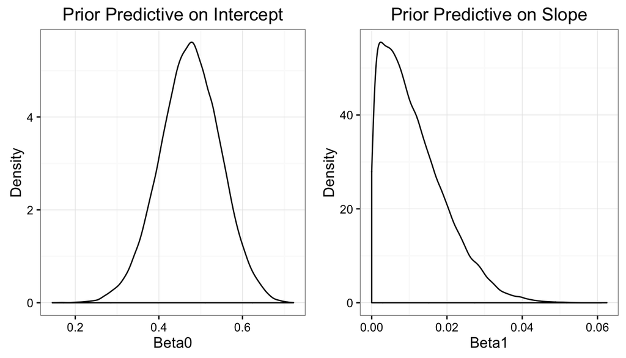

```r
a <- ggplot() + geom_density(aes(df_acc_age$beta1_prior)) +
    xlab("Beta1") +
    ylab("Density") +
    ggtitle("Prior Predictive on Slope")

b <- ggplot() + geom_density(aes(df_acc_age$beta0)) +
    xlab("Beta0") +
    ylab("Density") +
    ggtitle("Prior Predictive on Intercept")

gridExtra::grid.arrange(b, a, ncol = 2)
```

Plot prior with posterior on slope parameter.

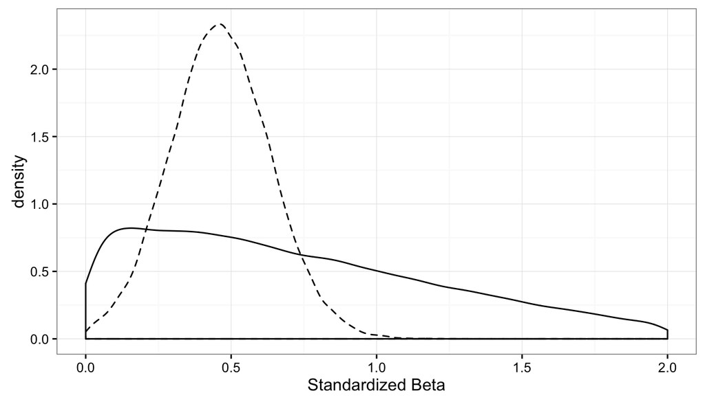

```r
ggplot(data=df_acc_age) +
    geom_density(aes(x=zbeta1), linetype='dashed') +
    geom_density(aes(x=zbeta1_prior), data = df_acc_age) +
    xlim(0,2) +
    xlab("Standardized Beta")
```

We can see that the prior model puts most of the density on a value of 0, or a null relationship between age and accuracy. It is truncated at zero to eoncode our directional hypothesis: that the slope parameter should be positive. And the prior does not consider extreme slope values beyond .04, or a 4% gain in accuracy with each month.

Now that we are confident that our prior distribution produces reasonable hypotheses, we can quantify the association between children’s age and accuracy on the VLP task.

The first question we ask is whether there is evidence of a linear relationship to measure. We answer this question by using the Savage-Dickey method for estimating the Bayes Factor. This method uses the statistical fact that the Bayes factor is the ratio of the prior and posterior at the point in the parameter space that reduces the full model to the nested model.

Thus, we treat the null model of no association between age and accuracy as a special case of the linear model where the slope parameter equals 0.

```r
# Compute p(D) for posterior and prior: Savage-Dickey Method to get Bayes Factor
# Fits a density using splines to approx. log-density
# uses 1997 knot and deletion algorithm
fit.posterior <- logspline(df_acc_age$zbeta1, lbound = 0)
posterior <- dlogspline(0, fit.posterior) # pdf @ beta=0

# get prior density using logspline
fit.prior <- logspline(df_acc_age$zbeta1_prior, lbound = 0)
prior <- dlogspline(0, fit.prior) # pdf @ beta=0
```

We get the Bayes Factor using the Savage-Dickey moethod as described in Wagenmakers et al. (2010), which takes the ratio of the density of the posterior and prior when the slope parameter is zero.

```r
# bayes factor
bf_acc_age <- posterior/prior
1/bf_acc_age
```

Now that we know there is evidence of a linear association, we can summarize the strength of the association and the uncertainty around plausible values for slope parameter.

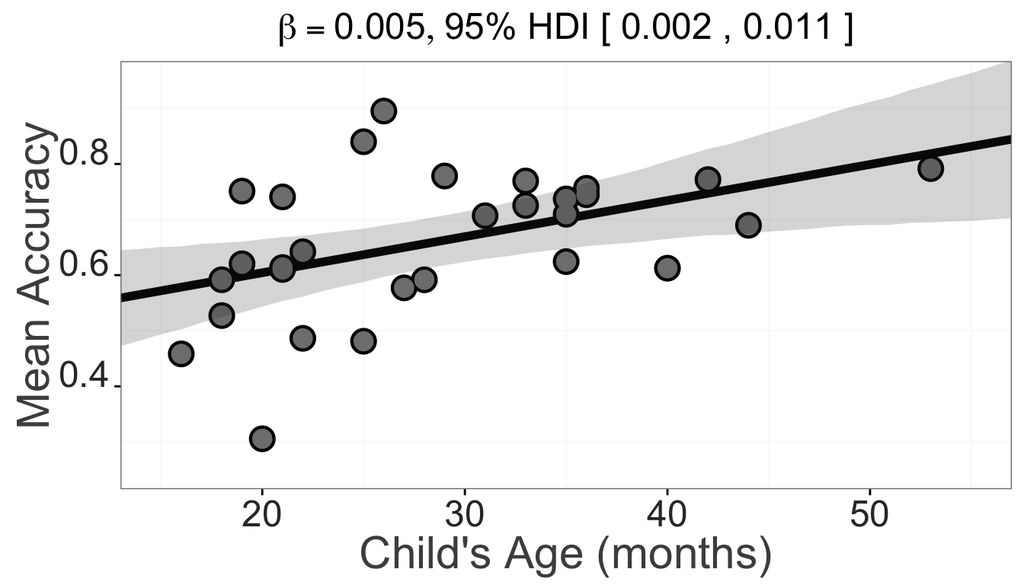

```r
post_mode_b1_acc_age <- round(find_mode(df_acc_age$beta1), 3)
post_mode_b0_acc_age <- round(find_mode(df_acc_age$beta0), 3)
HDI_b1_acc_age <- HDIofMCMC(df_acc_age$beta1 , credMass = 0.95 )

## simulate posterior distribution of mu for each value of age to get HDI for MAP regression line
mu.link <- function(x) {df_acc_age$beta0 + df_acc_age$beta1*x}
age.seq <- seq(from = 10, to = 60, by = 1)
mu <- sapply(age.seq, mu.link)
mu.mean <- apply(mu, 2, mean)
mu.HPDI <- apply(mu, 2, HPDI, prob = 0.95)
mu.HPDI_tidy <- data.frame(age_peek_months = age.seq,
                           hpdi_lower = mu.HPDI[1,], hpdi_upper = mu.HPDI[2,],
                           mu.mean = mu.mean)

ggplot(data = d) +
    geom_line(aes(x = age_peek_months, y = mu.mean), data = mu.HPDI_tidy, size = 2) +
    geom_point(aes(age_peek_months, mean_prop_looking_TD), color = "black", size = 5.5) +
    geom_point(aes(age_peek_months, mean_prop_looking_TD), color = "grey50", size = 4) +
    geom_ribbon(aes(x = age_peek_months, ymin = hpdi_lower, ymax = hpdi_upper), data = mu.HPDI_tidy,
                alpha = 0.2) +
    ylab("Mean Accuracy") +
    xlab("Child's Age (months)") +
    coord_cartesian(xlim=c(15, 55), ylim=c(0.25, 0.95)) +
    ggtitle(bquote(list(beta==.(as.character(round(post_mode_b1_acc_age, 3))),
                        HDI=.(paste("95% HDI [", round(HDI_b1_acc_age[1],3) , "," ,
                                     round(HDI_b1_acc_age[2], 3), "]"))))) +
    theme(plot.title = element_text(size = 18),
        axis.title.x = element_text(colour="grey30",size=22,
                                      angle=0,hjust=0.5,vjust=0,face="plain"),
          axis.title.y = element_text(colour="grey30",size=22,
                                      hjust=0.5,vjust=0.5,face="plain"),
          axis.text.x = element_text(colour="grey20",size=18,
                                     angle=0,hjust=0.5,vjust=0,face="plain"),
          axis.text.y = element_text(colour="grey20",size=18,
                                     angle=0,hjust=0.5,vjust=0,face="plain"),
          panel.grid.major=element_blank())
```

### Vocab and accuracy

Draw samples from the prior and posterior.

```r
dataList_acc_voc = list(
    y = d_voc$acc.s,
    x = d_voc$voc.s,
    Ntotal = length(d_voc$age.s)
)

parameters = c( "zbeta0" , "zbeta1" , "zsigma" , "zbeta1_prior" , "zbeta0_prior" )

samples <- jags(data = dataList_acc_voc, parameters.to.save = parameters,
                      model.file = "models/accuracy_model.txt", n.chains=nChains,
                      n.iter=nIter, n.burnin = burnInSteps,
                      n.thin=1, DIC=T)

df_acc_voc <- data.frame(zbeta0 = samples$BUGSoutput$sims.list$zbeta0,
                       zbeta1 = samples$BUGSoutput$sims.list$zbeta1,
                       zbeta0_prior = samples$BUGSoutput$sims.list$zbeta0_prior,
                       zbeta1_prior = samples$BUGSoutput$sims.list$zbeta1_prior)

# transform standardized prior to measurement scale
df_acc_voc %<>%
    mutate( beta1 = zbeta1 * sd(d_voc$mean_prop_looking_TD) / sd(d_voc$signs_produced),
            beta1_prior = zbeta1_prior * sd(d_voc$mean_prop_looking_TD) / sd(d_voc$signs_produced),
            beta0 = zbeta0 * sd(d_voc$mean_prop_looking_TD) + mean(d_voc$mean_prop_looking_TD) - (zbeta1 * mean(d_voc$signs_produced) * sd(d_voc$mean_prop_looking_TD)) / sd(d_voc$signs_produced),
            beta0_prior = zbeta0_prior * sd(d_voc$mean_prop_looking_TD) + mean(d_voc$mean_prop_looking_TD) - (zbeta1_prior * mean(d_voc$signs_produced) * sd(d_voc$mean_prop_looking_TD)) / sd(d_voc$signs_produced)
    )
```

Plot prior with posterior on slope parameter.

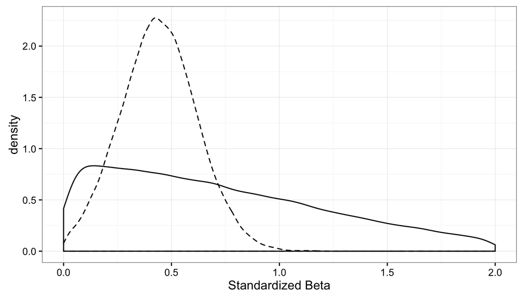

```r
ggplot(data=df_acc_voc) +
    geom_density(aes(x=zbeta1), linetype='dashed') +
    geom_density(aes(x=zbeta1_prior), data = df_acc_voc) +
    xlim(0,2) +
    xlab("Standardized Beta")
```

We get the Bayes Factor by taking the ratio of the density of the posterior and prior when the slope parameter is zero.

```r
fit.posterior <- logspline(df_acc_voc$beta1, lbound = 0)
posterior <- dlogspline(0, fit.posterior) # pdf @ beta=0

# get prior density using logspline
fit.prior <- logspline(df_acc_voc$beta1_prior, lbound = 0)
prior <- dlogspline(0, fit.prior) # pdf @ beta=0

bf_acc_voc <- posterior/prior # bayes factor
1/bf_acc_voc
```

Now that we know there is evidence of a linear association, we can summarize the strength of the association and the uncertainty around plausible values for slope parameter.

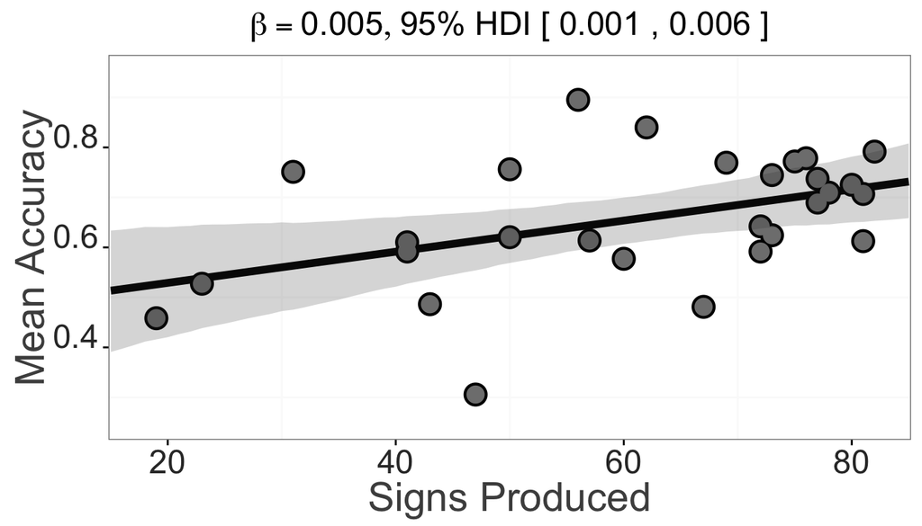

```r
## get MAP and HDI on slope and intercept
post_mode_b1_accvoc <- round(find_mode(df_acc_voc$beta1), 3)
post_mode_b0_accvoc <- round(find_mode(df_acc_voc$beta0), 3)
HDI_b1_accvoc <- HDIofMCMC(df_acc_voc$beta1 , credMass = 0.95 )

## simulate to get HDI for regression line
vocab.seq <- seq(from = 15, to = 85, by = 1)
mu.link <- function(x) {df_acc_voc$beta0 + df_acc_voc$beta1*x}
mu <- sapply(vocab.seq, mu.link)
mu.mean <- apply(mu, 2, mean)
mu.HPDI <- apply(mu, 2, HPDI, prob = 0.95)
mu.HPDI_tidy <- data.frame(signs_produced = vocab.seq, hpdi_lower = mu.HPDI[1,], hpdi_upper = mu.HPDI[2,])

ggplot(data = d_voc) +
    geom_line(aes(x = signs_produced, y = mu.mean), data = mu.HPDI_tidy, size = 2) +
    geom_point(aes(signs_produced, mean_prop_looking_TD), color = "black", size = 5.5) +
    geom_point(aes(signs_produced, mean_prop_looking_TD), color = "grey50", size = 4) +
    geom_ribbon(aes(x = signs_produced, ymin = hpdi_lower, ymax = hpdi_upper), data = mu.HPDI_tidy,
                alpha = 0.2) +
    ylab("Mean Accuracy") +
    xlab("Signs Produced") +
    coord_cartesian(xlim=c(18, 82), ylim=c(0.25, 0.95)) +
    ggtitle(bquote(list(beta==.(as.character(round(post_mode_b1_accvoc, 3))),
                        HDI=.(paste("95% HDI [", round(HDI_b1_accvoc[1],3) , "," ,
                                    round(HDI_b1_accvoc[2], 3), "]"))))) +
    theme(plot.title = element_text(size = 18),
        axis.title.x = element_text(colour="grey30",size=22,
                                      angle=0,hjust=0.5,vjust=0,face="plain"),
          axis.title.y = element_text(colour="grey30",size=22,
                                      hjust=0.5,vjust=0.5,face="plain"),
          axis.text.x = element_text(colour="grey20",size=18,
                                     angle=0,hjust=0.5,vjust=0,face="plain"),
          axis.text.y = element_text(colour="grey20",size=18,
                                     angle=0,hjust=0.5,vjust=0,face="plain"),
          panel.grid.major=element_blank())
```

### Age and RT

Draw samples from the prior and posterior.

```r
# Specify the data in a list, for later shipment to JAGS:
dataList_age_rt = list(
    x = d$age.s,
    y = d$rt.s,
    n_correct = d$C_T_count,
    n_trials = d$total_trials_shifting,
    Ntotal = length(d$acc.s)
)

parameters = c( "true_beta0" , "true_beta1", "true_beta0_prior", "true_beta1_prior", "z")

myinits <-  list(list(phi = 0.75, z = round(runif(length(d$total_trials_shifting)))))

samples <- jags(data = dataList_age_rt, parameters.to.save = parameters,
                model.file = "models/rt_model.txt", n.chains=nChains,
                n.iter=nIter, n.burnin = burnInSteps, inits = myinits,
                n.thin=1, DIC=T)


df_rt_age <- data.frame(zbeta0 = samples$BUGSoutput$sims.list$true_beta0,
                        zbeta1 = samples$BUGSoutput$sims.list$true_beta1,
                        zbeta0_prior = samples$BUGSoutput$sims.list$true_beta0_prior,
                        zbeta1_prior = samples$BUGSoutput$sims.list$true_beta1_prior,
                        z = samples$BUGSoutput$sims.list$z)

## transform to measurement scale (RT in ms)
df_rt_age %<>% mutate(
    beta1 = zbeta1 * sd(d$median_rt) / sd(d$age_peek_months),
    beta1_prior = zbeta1_prior * sd(d$median_rt) / sd(d$age_peek_months),
    beta0 = zbeta0 * sd(d$median_rt) + mean(d$median_rt) - zbeta1 * mean(d$age_peek_months) * sd(d$median_rt) / sd(d$age_peek_months),
    beta0_prior = zbeta0_prior * sd(d$median_rt) + mean(d$median_rt) - zbeta1_prior * mean(d$age_peek_months) * sd(d$median_rt) / sd(d$age_peek_months)
)
```

First, we plot samples from the prior predictive distribution to show that we are considering a plausible set of parameter values for the slope and interecept. Here we use past research on spoken language to inform our prior: that expected change in RT for each month of age is ~50ms.

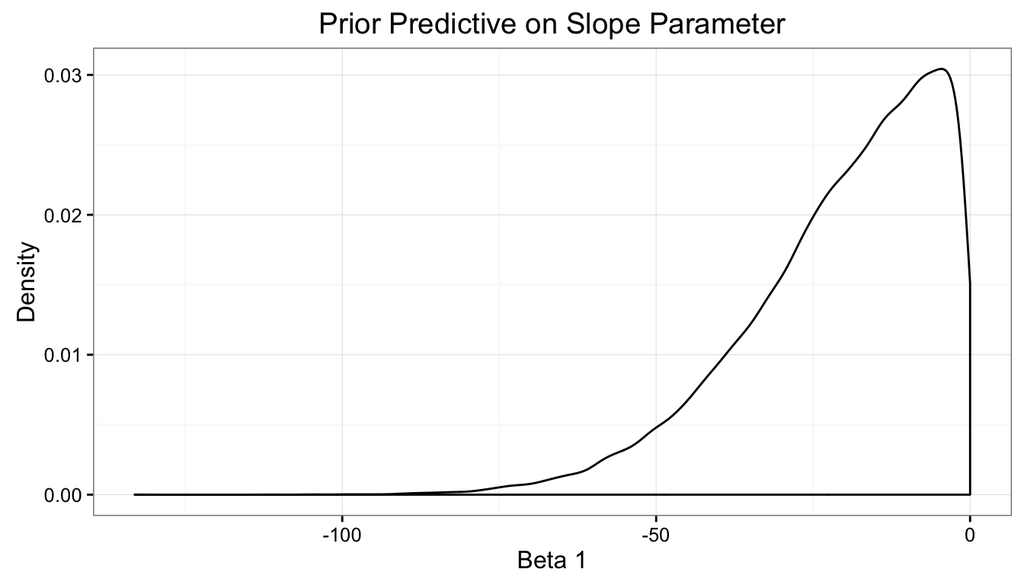

```r
ggplot() + geom_density(aes(df_rt_age$beta1_prior)) +
    xlab("Beta 1") +
    ylab("Density") +
    ggtitle("Prior Predictive on Slope Parameter")
```

Plot prior with posterior.

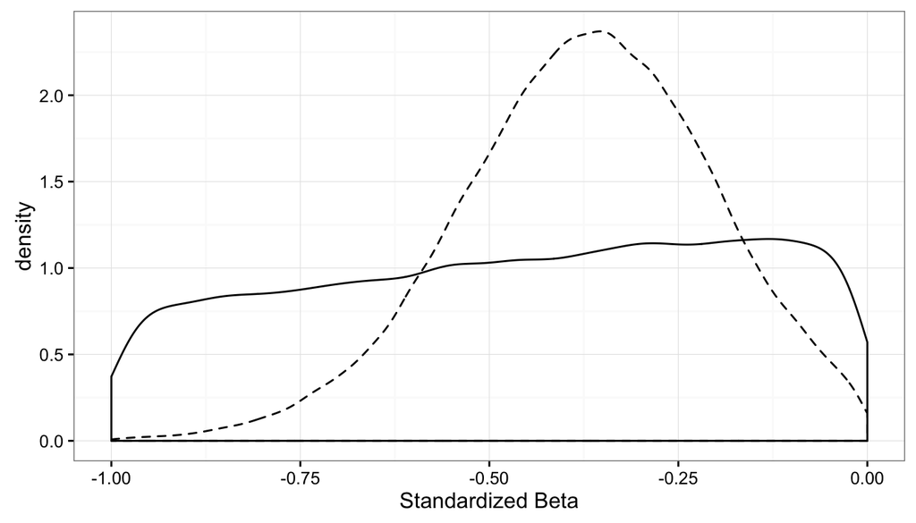

```r
ggplot(data=df_rt_age) +
    geom_density(aes(x=zbeta1), linetype='dashed') +
    geom_density(aes(x=zbeta1_prior), data = df_rt_age) +
    xlim(-1, 0) +
    xlab("Standardized Beta")
```

Get Bayes Factor using Savage-Dickey method.

```r
# Compute p(D) for posterior and prior: Savage-Dickey Method to get Bayes Factor
# Fits a density using splines to approx. log-density
# uses 1997 knot and deletion algorithm
fit.posterior <- logspline(df_rt_age$zbeta1, ubound = 0)
posterior <- dlogspline(0, fit.posterior) # pdf @ beta=0

# get prior density using logspline
fit.prior <- logspline(df_rt_age$zbeta1_prior, ubound = 0)
prior <- dlogspline(0, fit.prior) # pdf @ beta=0

bf_rt_age <- posterior / prior
1/bf_rt_age
```

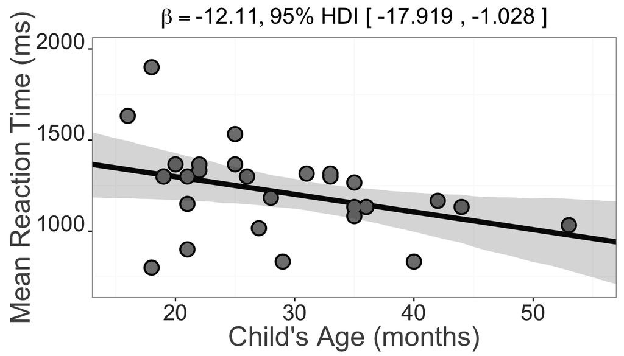

```r
HDI_rt_age_b1 <- HDIofMCMC(df_rt_age$beta1 , credMass = 0.95 )
post_rt_age_mode_b1 <- round(find_mode(df_rt_age$beta1), 3)
post_rt_age_mode_b0 <- round(find_mode(df_rt_age$beta0), 3)

# simulate to get HDI around MAP regression line
mu.link <- function(x) {df_rt_age$beta0 + df_rt_age$beta1*x}
age.seq <- seq(from = 10, to = 60, by = 1)
mu <- sapply(age.seq, mu.link)
mu.mean <- apply(mu, 2, mean)
mu.HPDI <- apply(mu, 2, HPDI, prob = 0.95)
mu.HPDI_tidy <- data.frame(age_peek_months = age.seq,
                           hpdi_lower = mu.HPDI[1,], hpdi_upper = mu.HPDI[2,],
                           mu.rt = mu.mean)

ggplot(data = d) +
    geom_line(aes(x = age_peek_months, y = mu.rt), data = mu.HPDI_tidy, size = 2) +
    geom_point(aes(age_peek_months, median_rt), color = "black", size = 5.5) +
    geom_point(aes(age_peek_months, median_rt), color = "grey50", size = 4) +
    geom_ribbon(aes(x = age_peek_months, ymin = hpdi_lower, ymax = hpdi_upper), data = mu.HPDI_tidy,
                alpha = 0.2) +
    ylab("Mean Reaction Time (ms)") +
    xlab("Child's Age (months)") +
    coord_cartesian(xlim=c(15, 55), ylim=c(700, 2000)) +
    ggtitle(bquote(list(beta==.(as.character(round(post_rt_age_mode_b1, 2))),
                        HDI=.(paste("95% HDI [", round(HDI_rt_age_b1[1],3) , "," ,
                                    round(HDI_rt_age_b1[2], 3), "]"))))) +
    theme(plot.title = element_text(size = 18),
        axis.title.x = element_text(colour="grey30",size=22,
                                      angle=0,hjust=0.5,vjust=0,face="plain"),
          axis.title.y = element_text(colour="grey30",size=22,
                                      hjust=0.5,vjust=0.5,face="plain"),
          axis.text.x = element_text(colour="grey20",size=18,
                                     angle=0,hjust=0.5,vjust=0,face="plain"),
          axis.text.y = element_text(colour="grey20",size=18,
                                     angle=0,hjust=0.5,vjust=0,face="plain"),
          panel.grid.major=element_blank())
```

### Vocab and RT

Draw samples from prior and posterior.

```r
dataList_voc_rt= list(
    x = d_voc$voc.s,
    y = d_voc$rt.s,
    n_correct = d_voc$C_T_count,
    n_trials = d_voc$total_trials_shifting,
    Ntotal = length(d_voc$voc.s)
)

myinits <-  list(list(phi = 0.75, z = round(runif(length(d_voc$total_trials_shifting)))))

samples <- jags(data = dataList_voc_rt, parameters.to.save = parameters,
                model.file = "models/rt_model.txt", n.chains=nChains, inits = myinits,
                n.iter=nIter, n.burnin = burnInSteps,
                n.thin=1, DIC=F)


df_rt_voc <- data.frame(zbeta0 = samples$BUGSoutput$sims.list$true_beta0,
                        zbeta1 = samples$BUGSoutput$sims.list$true_beta1,
                        zbeta0_prior = samples$BUGSoutput$sims.list$true_beta0_prior,
                        zbeta1_prior = samples$BUGSoutput$sims.list$true_beta1_prior,
                        z = samples$BUGSoutput$sims.list$z)

## transform to measurement scale (RT in ms)
df_rt_voc%<>% mutate(
    beta1 = zbeta1 * sd(d_voc$median_rt) / sd(d_voc$signs_produced),
    beta0 = zbeta0 * sd(d_voc$median_rt) + mean(d_voc$median_rt) - zbeta1 * mean(d_voc$signs_produced) * sd(d_voc$median_rt) / sd(d_voc$signs_produced),
    beta1_prior = zbeta1_prior * sd(d_voc$median_rt) / sd(d_voc$signs_produced),
    beta0_prior = zbeta0_prior * sd(d_voc$median_rt) + mean(d_voc$median_rt) - zbeta1_prior * mean(d_voc$signs_produced) * sd(d_voc$median_rt) / sd(d_voc$signs_produced)
)
```

Plot prior with posterior.

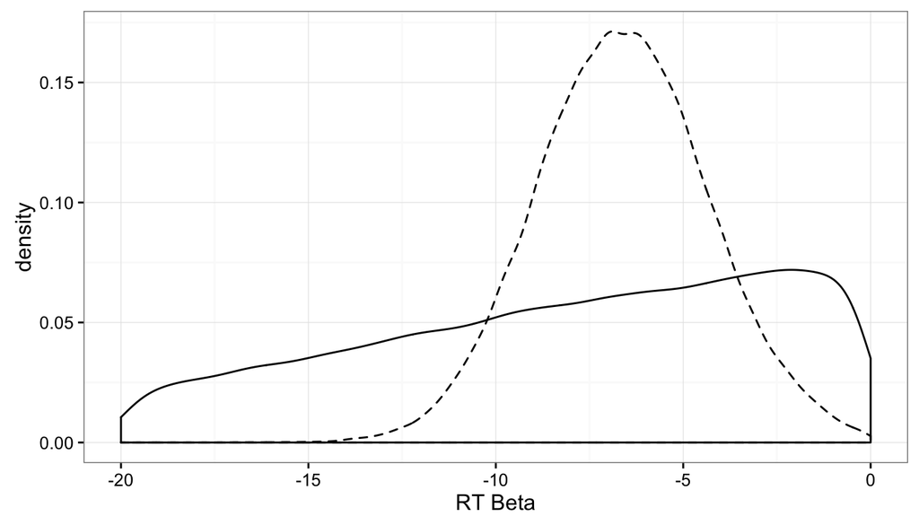

```r
ggplot(data=df_rt_voc) +
    geom_density(aes(x=beta1), linetype='dashed') +
    geom_density(aes(x=beta1_prior), data = df_rt_voc) +
    xlim(-20, 0) +
    xlab("RT Beta")
```

Get Bayes Factor.

```r
# Compute p(D) for posterior and prior: Savage-Dickey Method to get Bayes Factor
# Fits a density using splines to approx. log-density
# uses 1997 knot and deletion algorithm
fit.posterior <- logspline(df_rt_voc$zbeta1, ubound = 0)
posterior <- dlogspline(0, fit.posterior) # pdf @ beta=0

# get prior density using logspline
fit.prior <- logspline(df_rt_voc$zbeta1_prior, ubound = 0)
prior <- dlogspline(0, fit.prior) # pdf @ beta=0

bf_rt_voc <- posterior / prior
1/bf_rt_voc
```

Estimate strength of association.

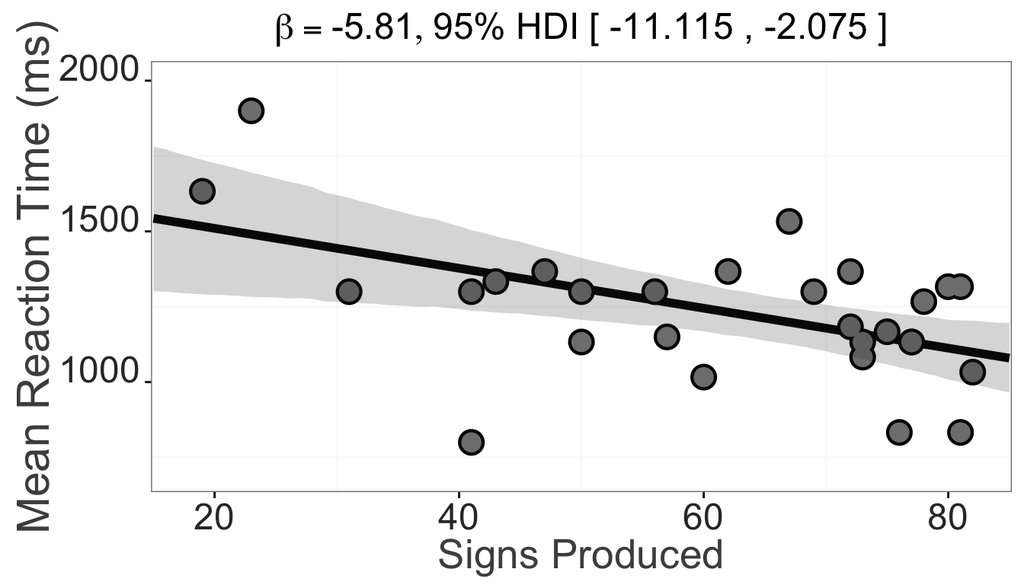

```r
HDI_rt_voc_b1 <- HDIofMCMC( df_rt_voc$beta1 , credMass = 0.95 )
post_mode_b1_rt_voc <- round(find_mode(df_rt_voc$beta1), 3)
post_mode_b0_rt_voc <- round(find_mode(df_rt_voc$beta0), 3)

vocab.seq <- seq(from = 15, to = 85, by = 1)
mu.link <- function(x) {df_rt_voc$beta0 + df_rt_voc$beta1*x}
mu <- sapply(vocab.seq, mu.link)
mu.mean <- apply(mu, 2, mean)
mu.HPDI <- apply(mu, 2, HPDI, prob = 0.95)
mu.HPDI_tidy <- data.frame(signs_produced = vocab.seq, hpdi_lower = mu.HPDI[1,], hpdi_upper = mu.HPDI[2,],
                           mu.rt = mu.mean)

# plot
ggplot(data = d_voc) +
    geom_line(aes(x = signs_produced, y = mu.mean), data = mu.HPDI_tidy, size = 2) +
    geom_point(aes(signs_produced, median_rt), color = "black", size = 5.5) +
    geom_point(aes(signs_produced, median_rt), color = "grey50", size = 4) +
    geom_ribbon(aes(x = signs_produced, ymin = hpdi_lower, ymax = hpdi_upper), data = mu.HPDI_tidy,
                alpha = 0.2) +
    ylab("Mean Reaction Time (ms)") +
    xlab("Signs Produced") +
    coord_cartesian(xlim=c(18, 82), ylim=c(700, 2000)) +
   ggtitle(bquote(list(beta==.(as.character(round(post_mode_b1_rt_voc, 2))),
                        HDI=.(paste("95% HDI [", round(HDI_rt_voc_b1[1],3) , "," ,
                                     round(HDI_rt_voc_b1[2], 3), "]")))))  +
    theme(plot.title = element_text(size=18),
        axis.title.x = element_text(colour="grey30",size=20,
                                      angle=0,hjust=0.5,vjust=0,face="plain"),
          axis.title.y = element_text(colour="grey30",size=22,
                                      hjust=0.5,vjust=0.5,face="plain"),
          axis.text.x = element_text(colour="grey20",size=18,
                                     angle=0,hjust=0.5,vjust=0,face="plain"),
          axis.text.y = element_text(colour="grey20",size=18,
                                     angle=0,hjust=0.5,vjust=0,face="plain"),
          panel.grid.major=element_blank())
```

### RT and Acc

```r
# Specify the data in a list, for later shipment to JAGS:
dataList_acc_rt = list(
    x = d$acc.s,
    y = d$rt.s,
    Ntotal = length(d$acc.s)
)

parameters = c( "zbeta0" , "zbeta1" , "zsigma" , "zbeta1_prior" , "zbeta0_prior" )

samples <- jags(data = dataList_acc_rt, parameters.to.save = parameters,
                      model.file = "models/rt_model_nomixture.txt", n.chains=nChains,
                      n.iter=nIter, n.burnin = burnInSteps,
                      n.thin=1, DIC=T)

df_rt_acc <- data.frame(zbeta0 = samples$BUGSoutput$sims.list$zbeta0,
                       zbeta1 = samples$BUGSoutput$sims.list$zbeta1,
                       zbeta0_prior = samples$BUGSoutput$sims.list$zbeta0_prior,
                       zbeta1_prior = samples$BUGSoutput$sims.list$zbeta1_prior)

## transform to measurement scale (RT in ms)
df_rt_acc %<>% mutate(
    beta1 = zbeta1 * sd(d$median_rt) / sd(d$mean_prop_looking_TD),
    beta1_prior = zbeta1_prior * sd(d$median_rt) / sd(d$mean_prop_looking_TD),
    beta0 = zbeta0 * sd(d$median_rt) + mean(d$median_rt) - zbeta1 * mean(d$mean_prop_looking_TD) * sd(d$median_rt) / sd(d$mean_prop_looking_TD),
    beta0_prior = zbeta0_prior * sd(d$median_rt) + mean(d$median_rt) - zbeta1_prior * mean(d$mean_prop_looking_TD) * sd(d$median_rt) / sd(d$mean_prop_looking_TD)
)
```

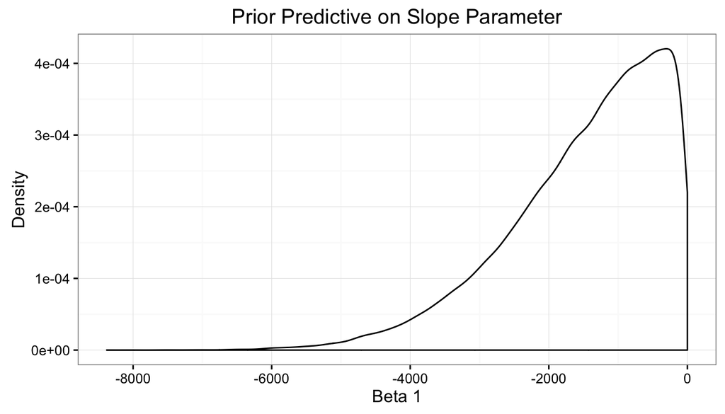

```r
ggplot() + geom_density(aes(df_rt_acc$beta1_prior)) +
    xlab("Beta 1") +
    ylab("Density") +
    ggtitle("Prior Predictive on Slope Parameter")
```

Plot prior with posterior.

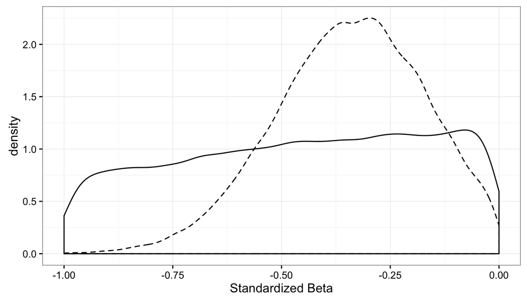

```r
ggplot(data=df_rt_acc) +
    geom_density(aes(x=zbeta1), linetype='dashed') +
    geom_density(aes(x=zbeta1_prior), data = df_rt_acc) +
    xlim(-1, 0) +
    xlab("Standardized Beta")
```

Get Bayes Factor using Savage-Dickey method.

```r
# Compute p(D) for posterior and prior: Savage-Dickey Method to get Bayes Factor
# Fits a density using splines to approx. log-density
# uses 1997 knot and deletion algorithm
fit.posterior <- logspline(df_rt_acc$zbeta1, ubound = 0)
posterior <- dlogspline(0, fit.posterior) # pdf @ beta=0

# get prior density using logspline
fit.prior <- logspline(df_rt_acc$zbeta1_prior, ubound = 0)
prior <- dlogspline(0, fit.prior) # pdf @ beta=0

bf_rt_acc <- posterior / prior
1/bf_rt_acc
```

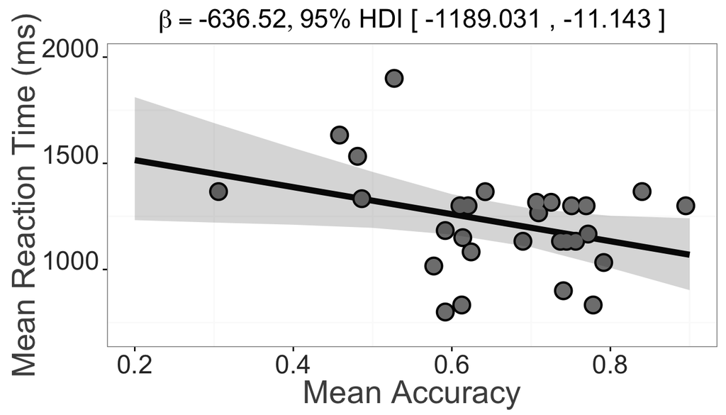

```r
HDI_rt_acc_b1 <- HDIofMCMC(df_rt_acc$beta1 , credMass = 0.95 )
post_rt_acc_mode_b1 <- round(mean(df_rt_acc$beta1), 3)
post_rt_acc_mode_b0 <- round(mean(df_rt_acc$beta0), 3)

# simulate to get HDI around MAP regression line
mu.link <- function(x) {df_rt_acc$beta0 + df_rt_acc$beta1*x}
acc.seq <- seq(from = 0.2, to = 0.9, by = 0.1)
mu <- sapply(acc.seq, mu.link)
mu.mean <- apply(mu, 2, mean)
mu.HPDI <- apply(mu, 2, HPDI, prob = 0.95)
mu.HPDI_tidy <- data.frame(mean_prop_looking_TD = acc.seq,
                           hpdi_lower = mu.HPDI[1,], hpdi_upper = mu.HPDI[2,],
                           mu.rt = mu.mean)

ggplot(data = d) +
    geom_line(aes(x = mean_prop_looking_TD, y = mu.rt), data = mu.HPDI_tidy, size = 2) +
    geom_point(aes(mean_prop_looking_TD, median_rt), color = "black", size = 5.5) +
    geom_point(aes(mean_prop_looking_TD, median_rt), color = "grey50", size = 4) +
    geom_ribbon(aes(x = mean_prop_looking_TD, ymin = hpdi_lower, ymax = hpdi_upper), data = mu.HPDI_tidy,
                alpha = 0.2) +
    ylab("Mean Reaction Time (ms)") +
    xlab("Mean Accuracy") +
    coord_cartesian(xlim=c(0.2, 0.9), ylim=c(700, 2000)) +
    ggtitle(bquote(list(beta==.(as.character(round(post_rt_acc_mode_b1, 2))),
                        HDI=.(paste("95% HDI [", round(HDI_rt_acc_b1[1],3) , "," ,
                                    round(HDI_rt_acc_b1[2], 3), "]"))))) +
    theme(plot.title = element_text(size = 18),
        axis.title.x = element_text(colour="grey30",size=22,
                                      angle=0,hjust=0.5,vjust=0,face="plain"),
          axis.title.y = element_text(colour="grey30",size=22,
                                      hjust=0.5,vjust=0.5,face="plain"),
          axis.text.x = element_text(colour="grey20",size=18,
                                     angle=0,hjust=0.5,vjust=0,face="plain"),
          axis.text.y = element_text(colour="grey20",size=18,
                                     angle=0,hjust=0.5,vjust=0,face="plain"),
          panel.grid.major=element_blank())
```

### Age and RT no latent mixture

Draw samples from prior and posterior.

```r
# Specify the data in a list, for later shipment to JAGS:
dataList_age_rt_nolat = list(
    x = d$age.s,
    y = d$rt.s,
    Ntotal = length(d$acc.s)
)

parameters = c( "zbeta0", "zbeta1", "zbeta0_prior", "zbeta1_prior")

samples <- jags(data = dataList_age_rt_nolat, parameters.to.save = parameters,
                model.file = "models/rt_model_nomixture.txt", n.chains=nChains,
                n.iter=nIter, n.burnin = burnInSteps,
                n.thin=1, DIC=F)


df_rt_age_nolat <- data.frame(zbeta0 = samples$BUGSoutput$sims.list$zbeta0,
                              zbeta1 = samples$BUGSoutput$sims.list$zbeta1,
                              zbeta0_prior = samples$BUGSoutput$sims.list$zbeta0_prior,
                              zbeta1_prior = samples$BUGSoutput$sims.list$zbeta1_prior)

## transform to measurement scale (RT in ms)
df_rt_age_nolat %<>% mutate(
    beta1 = zbeta1 * sd(d$median_rt) / sd(d$age_peek_months),
    beta0 = zbeta0 * sd(d$median_rt) + mean(d$median_rt) - zbeta1 * mean(d$age_peek_months) * sd(d$median_rt) / sd(d$age_peek_months),
    beta1_prior = zbeta1_prior * sd(d$median_rt) / sd(d$age_peek_months),
    beta0_prior = zbeta0_prior * sd(d$median_rt) + mean(d$median_rt) - zbeta1_prior * mean(d$age_peek_months) * sd(d$median_rt) / sd(d$age_peek_months)
)
```

Plot prior with posterior for slope parameter

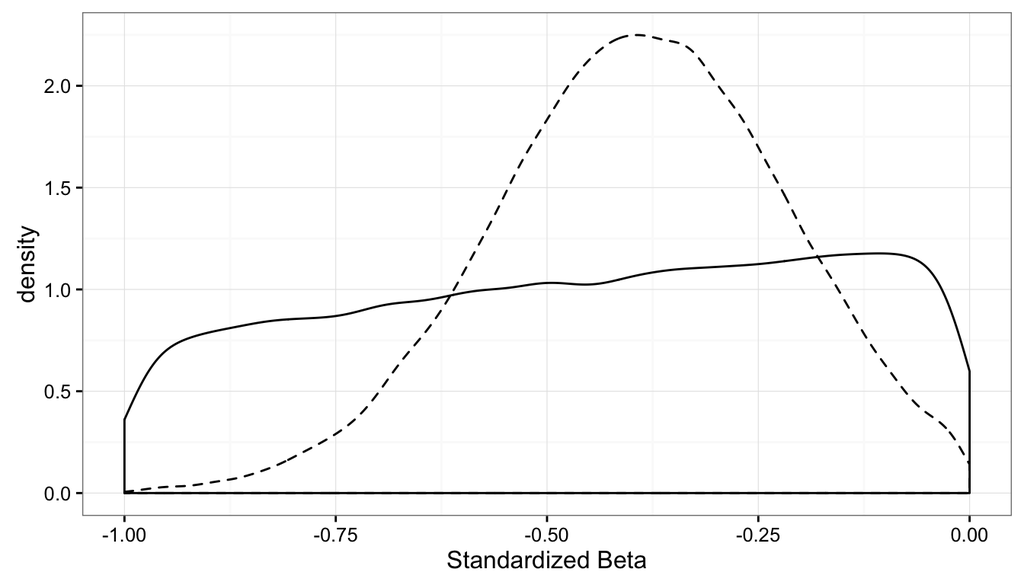

```r
ggplot(data=df_rt_age_nolat) +
    geom_density(aes(x=zbeta1), linetype='dashed') +
    geom_density(aes(x=zbeta1_prior), data = df_rt_age_nolat) +
    xlim(-1, 0) +
    xlab("Standardized Beta")
```

Compute Bayes Factor

```r
# Compute p(D) for posterior and prior: Savage-Dickey Method to get Bayes Factor
# Fits a density using splines to approx. log-density
# uses 1997 knot and deletion algorithm
fit.posterior <- logspline(df_rt_age_nolat$zbeta1, ubound = 0)
posterior <- dlogspline(0, fit.posterior) # pdf @ beta=0

# get prior density using logspline
fit.prior <- logspline(df_rt_age_nolat$zbeta1_prior, ubound = 0)
prior <- dlogspline(0, fit.prior) # pdf @ beta=0

bf_rt_age_nolat <- posterior / prior
1/bf_rt_age_nolat
```

Plot.

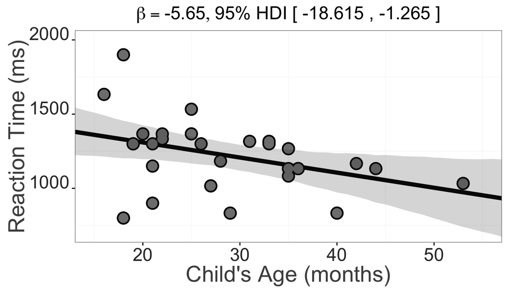

```r
HDI_rt_age_b1 <- HDIofMCMC(df_rt_age_nolat$beta1 , credMass = 0.95 )
post_rt_age_mode_b1 <- round(find_mode(df_rt_age_nolat$beta1), 3)
post_rt_age_mode_b0 <- round(find_mode(df_rt_age_nolat$beta0), 3)

# simulate to get HDI around MAP regression line
mu.link <- function(x) {df_rt_age_nolat$beta0 + df_rt_age_nolat$beta1*x}
age.seq <- seq(from = 10, to = 60, by = 1)
mu <- sapply(age.seq, mu.link)
mu.mean <- apply(mu, 2, mean)
mu.HPDI <- apply(mu, 2, HPDI, prob = 0.95)
mu.HPDI_tidy <- data.frame(age_peek_months = age.seq,
                           hpdi_lower = mu.HPDI[1,], hpdi_upper = mu.HPDI[2,],
                           mu.rt = mu.mean)

ggplot(data = d) +
    geom_line(aes(x = age_peek_months, y = mu.rt), data = mu.HPDI_tidy, size = 2) +
    geom_point(aes(age_peek_months, median_rt), color = "black", size = 5.5) +
    geom_point(aes(age_peek_months, median_rt), color = "grey50", size = 4) +
    geom_ribbon(aes(x = age_peek_months, ymin = hpdi_lower, ymax = hpdi_upper), data = mu.HPDI_tidy,
                alpha = 0.2) +
    ylab("Reaction Time (ms)") +
    xlab("Child's Age (months)") +
    coord_cartesian(xlim=c(15, 55), ylim=c(700, 2000)) +
    ggtitle(bquote(list(beta==.(as.character(round(post_rt_age_mode_b1, 2))),
                        HDI=.(paste("95% HDI [", round(HDI_rt_age_b1[1],3) , "," ,
                                    round(HDI_rt_age_b1[2], 3), "]"))))) +
    theme(plot.title = element_text(size = 18),
        axis.title.x = element_text(colour="grey30",size=22,
                                      angle=0,hjust=0.5,vjust=0,face="plain"),
          axis.title.y = element_text(colour="grey30",size=22,
                                      hjust=0.5,vjust=0.5,face="plain"),
          axis.text.x = element_text(colour="grey20",size=18,
                                     angle=0,hjust=0.5,vjust=0,face="plain"),
          axis.text.y = element_text(colour="grey20",size=18,
                                     angle=0,hjust=0.5,vjust=0,face="plain"),
          panel.grid.major=element_blank())
```

### Vocab and RT no latent mixture

Fit prior and posterior.

```r
# Specify the data in a list, for later shipment to JAGS:
dataList_voc_rt_nolat = list(
    x = d_voc$voc.s,
    y = d_voc$rt.s,
    Ntotal = length(d_voc$voc.s)
)

samples <- jags(data = dataList_voc_rt_nolat, parameters.to.save = parameters,
                model.file = "models/rt_model_nomixture.txt", n.chains=nChains,
                n.iter=nIter, n.burnin = burnInSteps,
                n.thin=1, DIC=F)


df_rt_voc_nolat <- data.frame(zbeta0 = samples$BUGSoutput$sims.list$zbeta0,
                              zbeta1 = samples$BUGSoutput$sims.list$zbeta1,
                              zbeta0_prior = samples$BUGSoutput$sims.list$zbeta0_prior,
                              zbeta1_prior = samples$BUGSoutput$sims.list$zbeta1_prior)

## transform to measurement scale (RT in ms)
df_rt_voc_nolat %<>% mutate(
    beta1 = zbeta1 * sd(d_voc$median_rt) / sd(d_voc$signs_produced),
    beta0 = zbeta0 * sd(d_voc$median_rt) + mean(d_voc$median_rt) - zbeta1 * mean(d_voc$signs_produced) * sd(d_voc$median_rt) / sd(d_voc$signs_produced),
    beta1_prior = zbeta1_prior * sd(d_voc$median_rt) / sd(d_voc$signs_produced),
    beta0_prior = zbeta0_prior * sd(d_voc$median_rt) + mean(d_voc$median_rt) - zbeta1_prior * mean(d_voc$signs_produced) * sd(d_voc$median_rt) / sd(d_voc$signs_produced)
)
```

Plot prior with posterior

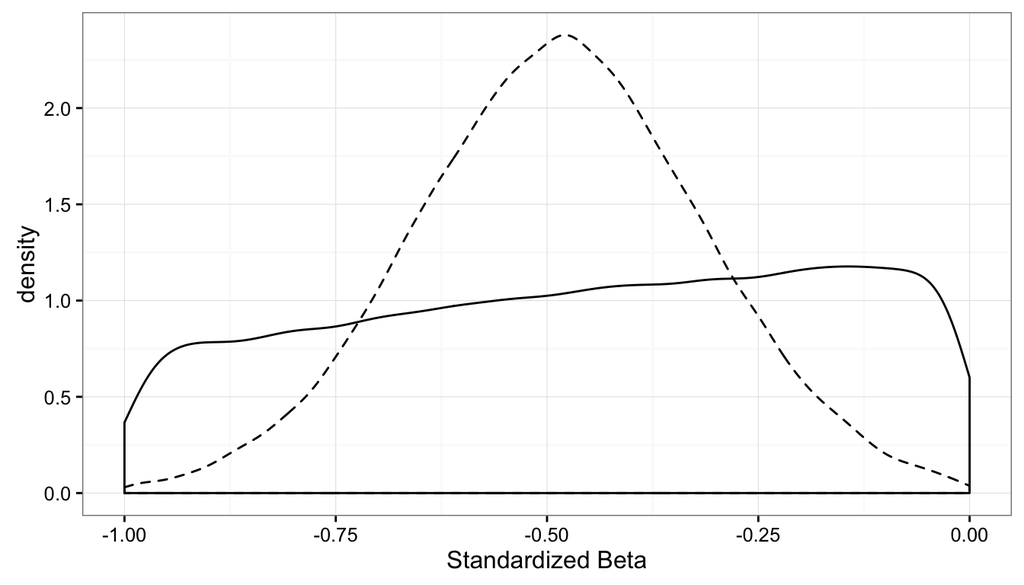

```r
ggplot(data=df_rt_voc_nolat) +
    geom_density(aes(x=zbeta1), linetype='dashed') +
    geom_density(aes(x=zbeta1_prior), data = df_rt_voc_nolat) +
    xlim(-1, 0) +
    xlab("Standardized Beta")
```

Compute Bayes Factor

```r
# Compute p(D) for posterior and prior: Savage-Dickey Method to get Bayes Factor
# Fits a density using splines to approx. log-density
# uses 1997 knot and deletion algorithm
fit.posterior <- logspline(df_rt_voc_nolat$zbeta1, ubound = 0)
posterior <- dlogspline(0, fit.posterior) # pdf @ beta=0

# get prior density using logspline
fit.prior <- logspline(df_rt_voc_nolat$zbeta1_prior, ubound = 0)
prior <- dlogspline(0, fit.prior) # pdf @ beta=0

bf_rt_voc_nolat <- posterior / prior
1/bf_rt_voc_nolat
```

Plot.

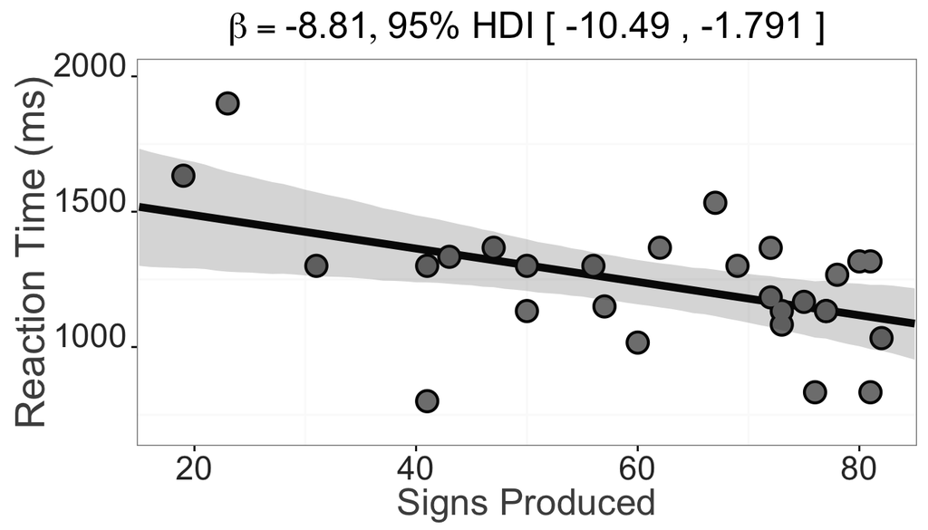

```r
HDI_rt_voc_b1 <- HDIofMCMC( df_rt_voc_nolat$beta1 , credMass = 0.95 )
post_mode_b1_rt_voc <- round(find_mode(df_rt_voc_nolat$beta1), 3)
post_mode_b0_rt_voc <- round(find_mode(df_rt_voc_nolat$beta0), 3)

vocab.seq <- seq(from = 15, to = 85, by = 1)
mu.link <- function(x) {df_rt_voc_nolat$beta0 + df_rt_voc_nolat$beta1*x}
mu <- sapply(vocab.seq, mu.link)
mu.mean <- apply(mu, 2, mean)
mu.HPDI <- apply(mu, 2, HPDI, prob = 0.95)
mu.HPDI_tidy <- data.frame(signs_produced = vocab.seq,
                           hpdi_lower = mu.HPDI[1,],
                           hpdi_upper = mu.HPDI[2,],
                           mu.rt = mu.mean)

# plot
ggplot(data = d_voc) +
    geom_line(aes(x = signs_produced, y = mu.mean), data = mu.HPDI_tidy, size = 2) +
    geom_point(aes(signs_produced, median_rt), color = "black", size = 5.5) +
    geom_point(aes(signs_produced, median_rt), color = "grey50", size = 4) +
    geom_ribbon(aes(x = signs_produced, ymin = hpdi_lower, ymax = hpdi_upper), data = mu.HPDI_tidy,
                alpha = 0.2) +
    ylab("Reaction Time (ms)") +
    xlab("Signs Produced") +
    coord_cartesian(xlim=c(18, 82), ylim=c(700, 2000)) +
   ggtitle(bquote(list(beta==.(as.character(round(post_mode_b1_rt_voc, 2))),
                        HDI=.(paste("95% HDI [", round(HDI_rt_voc_b1[1],3) , "," ,
                                     round(HDI_rt_voc_b1[2], 3), "]")))))  +
    theme(plot.title = element_text(size=20),
        axis.title.x = element_text(colour="grey30",size=20,
                                      angle=0,hjust=0.5,vjust=0,face="plain"),
          axis.title.y = element_text(colour="grey30",size=22,
                                      hjust=0.5,vjust=0.5,face="plain"),
          axis.text.x = element_text(colour="grey20",size=18,
                                     angle=0,hjust=0.5,vjust=0,face="plain"),
          axis.text.y = element_text(colour="grey20",size=18,
                                     angle=0,hjust=0.5,vjust=0,face="plain"),
          panel.grid.major=element_blank())
```

### Table of model summaries

```r
models <- c("Acc ~ Age", "Acc ~ Voc", "RT ~ Age", "RT ~ Voc")
bfs <- c(1/bf_acc_age, 1/bf_acc_voc, 1/bf_rt_age, 1/bf_rt_voc)
bmaps <- c(post_mode_b1_acc_age, post_mode_b1_accvoc, post_rt_age_mode_b1, post_mode_b1_rt_voc)
hdi_lower <- c(HDI_b1_acc_age[1], HDI_b1_accvoc[1], HDI_rt_age_b1[1], HDI_rt_voc_b1[1])
hdi_upper <- c(HDI_b1_acc_age[2], HDI_b1_accvoc[2], HDI_rt_age_b1[2], HDI_rt_voc_b1[2])

table1 <- data.frame(models, bfs, bmaps, hdi_lower, hdi_upper)

knitr::kable(table1, digits = 3)
```

[output not shown]

### Output of latent mixture models inferring guessing probability

Here we show the stability of our inferences about participants’ guessing behavior across the three different implementations of the latent mixture models:

- Without linear regression
- In the RT ~ Age model
- In the RT ~ Vocab model

First, we run latent mixture model by itself not conditioning on RT or accuracy data.

```r
dataList_lat_mix = list(
    n_correct = d$C_T_count,
    n_trials = d$total_trials_shifting,
    Ntotal = length(d$acc.s)
)

myinits <-  list(list(phi = 0.75, z = round(runif(length(d$total_trials_shifting)))))

parameters <- c("z")

samples_post <- jags(data = dataList_lat_mix, parameters.to.save = parameters,
                model.file = "models/latent_mixture.txt", n.chains=nChains, inits = myinits,
                n.iter=nIter, n.burnin = burnInSteps,
                n.thin=1, DIC=T)

df_latent_mix <- data.frame(z = samples_post$BUGSoutput$sims.list$z)

# grab subject numbers and add to data frame
colnames(df_latent_mix)[which(names(df_latent_mix)=="z.1"):which(names(df_latent_mix)=="z.29")] <- as.character(d$Sub.Num)

# melt data frame
df_melt <- reshape::melt.data.frame(df_latent_mix[,2:length(df_latent_mix)], variable.name = "Sub.Num", value.name = "group_membership")

# change factor label
df_melt %<>% mutate(group_membership_factor = factor(df_melt$value, labels = c("G", "K")),
                    model = "latent_mix")
```

Now do the same thing but for the RT ~ Age model.

```r
df_latent_mix <- select(df_rt_age, z.1:z.29)

# grab subject numbers and add to data frame
colnames(df_latent_mix)[which(names(df_latent_mix)=="z.1"):which(names(df_latent_mix)=="z.29")] <- as.character(d$Sub.Num)

# melt data frame
df_melt_rt_age <- reshape::melt.data.frame(df_latent_mix[,2:length(df_latent_mix)], variable.name = "Sub.Num", value.name = "group_membership")

# change factor label
df_melt_rt_age %<>% mutate(group_membership_factor = factor(df_melt_rt_age$value, labels = c("G", "K")),
                           model = "rt_age")
```

Now do the same thing but for the RT ~ Vocab model.

```r
df_latent_mix <- select(df_rt_voc, z.1:z.28)

# grab subject numbers and add to data frame
colnames(df_latent_mix)[which(names(df_latent_mix)=="z.1"):which(names(df_latent_mix)=="z.28")] <- as.character(d_voc$Sub.Num)

# melt data frame
df_melt_rt_voc <- reshape::melt.data.frame(df_latent_mix[,2:length(df_latent_mix)], variable.name = "Sub.Num", value.name = "group_membership")

# change factor label
df_melt_rt_voc %<>% mutate(group_membership_factor = factor(df_melt_rt_voc$value, labels = c("G", "K")),
                           model = "rt_voc")
```

Once we have all the simulation data, we can check the stability of the latent mixture model across the three different analyses.

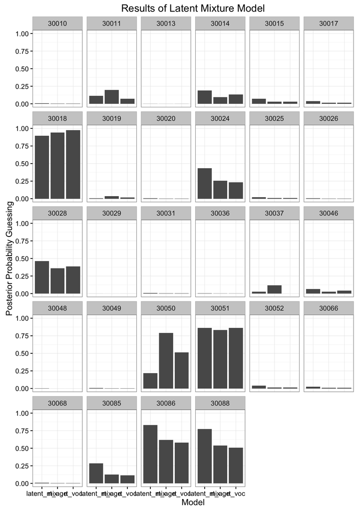

```r
df_all_sims <- rbind(df_melt, df_melt_rt_voc, df_melt_rt_age)

## summarise
ms_all_sims <- df_all_sims %>%
    group_by(variable, model) %>%
    summarise(prop_guessing = (length(value) - sum(value)) / length(value)) %>%
    mutate(prop_guessing_convert = prop_guessing * .1)

ggplot(data=ms_all_sims,aes(x=model, y = prop_guessing)) +
    geom_bar(stat="identity") +
    facet_wrap(~variable,scales='fixed') +
    guides(fill=F) +
    langcog::scale_fill_solarized() +
    ylim(0,1) +
    theme_bw()+
    xlab('Model') +
    ylab("Posterior Probability Guessing") +
    ggtitle("Results of Latent Mixture Model")
```

The estimates are relatively stable across the different models. Most participants are not likely to be guessing. Four participants have a high probability of guessing across all models and are thus less likely to contribute to the linear regression. 30050 is more likely to be guessing in the models with the linear regressions.

References

Kruschke, John. 2014. *Doing Bayesian Data Analysis: A Tutorial with R, JAGS, and Stan*. Academic Press.

Lee, Michael D, and Eric-Jan Wagenmakers. 2014. *Bayesian Cognitive Modeling: A Practical Course*. Cambridge University Press.

McElreath, Richard. 2016. *Statistical Rethinking: A Bayesian Course with Examples in R and Stan*. Vol. 122. CRC Press.

Plummer, Martyn, and others. 2003. “JAGS: A Program for Analysis of Bayesian Graphical Models Using Gibbs Sampling.” In *Proceedings of the 3rd International Workshop on Distributed Statistical Computing*, 124:125. Technische Universit at Wien Wien, Austria.

Team, Stan Development. 2016. “RStan: The R Interface to Stan, Version 2.9.0.” http://mc-stan.org.

Wagenmakers, Eric-Jan, Tom Lodewyckx, Himanshu Kuriyal, and Raoul Grasman. 2010. “Bayesian Hypothesis Testing for Psychologists: A Tutorial on the Savage–Dickey Method.” *Cognitive Psychology* 60 (3). Elsevier: 158–89.